# Creating plots in R using ggplot2 - part 9: function plots

Jodie Burchell

Mauricio Vargas Sepúlveda 帕夏

2016-03-28

This is the ninth tutorial in a series on using `ggplot2` I am creating with [Mauricio Vargas Sepúlveda](http://pachamaltese.github.io/). In this tutorial we will demonstrate some of the many options the `ggplot2` package has for plotting and customising functions.

In this tutorial, we will work towards creating the function plot below. We will take you from a basic function plot and explain all the customisations we add to the code step-by-step.

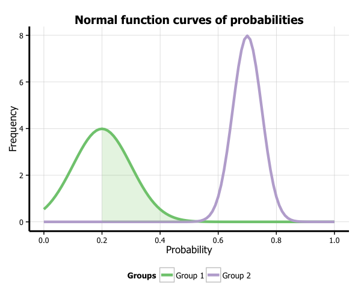

### Basic normal curve

In order to create a normal curve, we create a ggplot base layer that has an x-axis range from -4 to 4 (or whatever range you want!), and assign the x-value aesthetic to this range (`aes(x = x)`). We then add the `stat_function` option and add `dnorm` to the function argument to make it a normal curve.

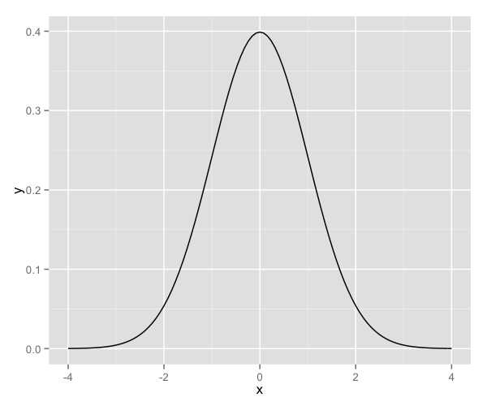

```r
p9 <- ggplot(data.frame(x = c(-4, 4)), aes(x = x)) +
        stat_function(fun = dnorm)
p9
```

### Basic t- curve

`stat_function` can draw a range of continuous [probability density functions](https://en.wikipedia.org/wiki/Probability_density_function), including t (`dt`), F (`df`) and Chi-square (`dchisq`) PDFs. Here we will plot a t-distribution. As the shape of the t-distribution changes depending on the sample size (indicated by the degrees of freedom, or df), we need to specify our df value as part of defining our curve.

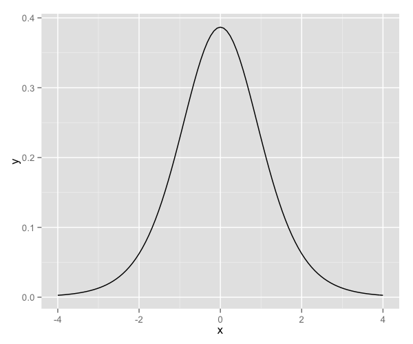

```r
p9 <- ggplot(data.frame(x = c(-4, 4)), aes(x = x)) +
        stat_function(fun = dt, args = list(df = 8))
p9
```

### Plotting your own function

You can also draw your own function, as long as it takes the form of a formula that converts an x-value into a y-value. Here we have plotted a curve that returns y-values that are the cube of x times a half:

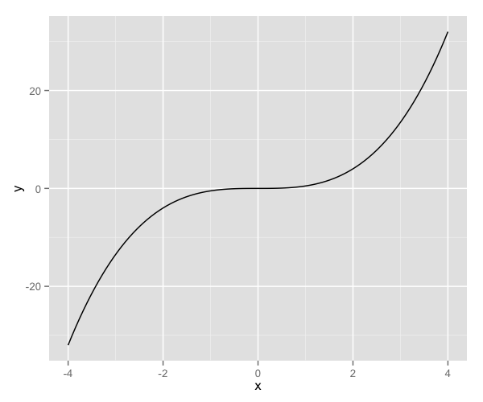

```r
cubeFun <- function(x) {
    x^3 * 0.5
}

p9 <- ggplot(data.frame(x = c(-4, 4)), aes(x = x)) +
        stat_function(fun = cubeFun)
p9
```

### Plotting multiple functions on the same graph

You can plot multiple functions on the same graph by simply adding another `stat_function()` for each curve. Here we have plotted two normal curves on the same graph, one with a mean of 0.2 and a standard deviation of 0.1, and one with a mean of 0.7 and a standard deviation of 0.05. (Note that the `dnorm` function has a default mean of 0 and a default standard deviation of 1, which is why we didn’t need to explicitly define them in the first normal curve we plotted above.) You can also see we’ve changed the range of the x-axis to between 0 and 1.

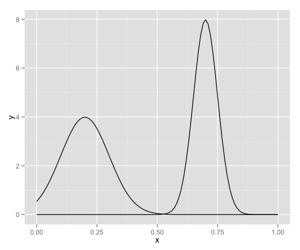

```r
p9 <- ggplot(data.frame(x = c(0, 1)), aes(x = x)) +
        stat_function(fun = dnorm, args = list(0.2, 0.1)) +
        stat_function(fun = dnorm, args = list(0.7, 0.05))
p9
```

### Customising axis labels

Let’s move forward with this two function graph, and start tweaking the appearance. In order to change the axis labels, we have a couple of options. In this case, we have used the `scale_x_continuous` and `scale_y_continuous` options, as these have further customisation options for the axes we will use below. In each, we add the desired name to the `name` argument as a string.

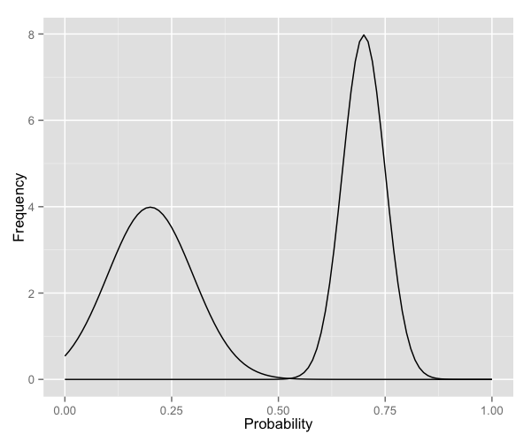

```r
p9 <- p9 + scale_x_continuous(name = "Probability") +
        scale_y_continuous(name = "Frequency")
p9
```

### Changing axis ticks

The next thing we will change is the axis ticks. Let’s make the x-axis ticks appear at every 0.2 units rather than 0.25 using the `breaks = seq(0, 1, 0.2)` argument in `scale_x_continuous`. (The `seq` function is a base R function that indicates the start and endpoints and the units to increment by respectively. See `help(seq)` for more information.) We ensure that the x-axis begins and ends where we want by also adding the argument `limits = c(0, 1)` to `scale_x_continuous`.

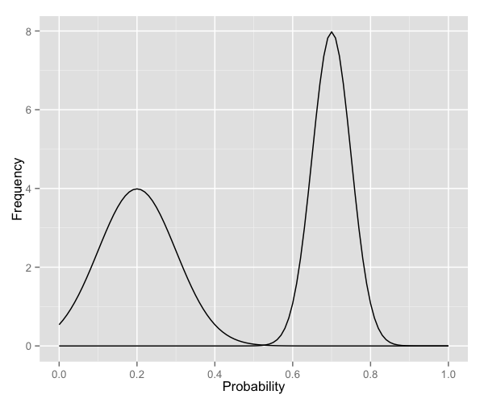

```r
p9 <- p9 + scale_x_continuous(name = "Probability",
                              breaks = seq(0, 1, 0.2),
                              limits=c(0, 1)) +
        scale_y_continuous(name = "Frequency")
p9
```

### Adding a title

To add a title, we include the option `ggtitle` and include the name of the graph as a string argument.

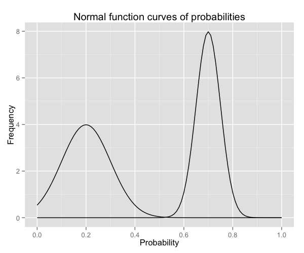

```r
p9 <- p9 + ggtitle("Normal function curves of probabilities")
p9
```

### Changing the colour of the curves

To change the line colours of the curves, we add a valid colour to the `colour` arguments in `stat_function`. A list of valid colours is [here](http://www.stat.columbia.edu/~tzheng/files/Rcolor.pdf).

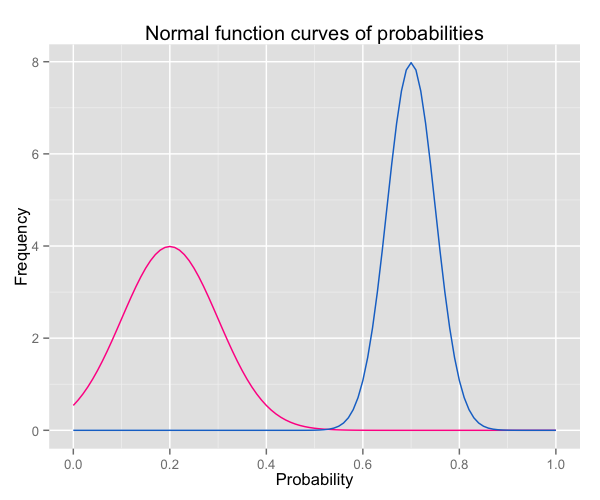

```r
p9 <- ggplot(data.frame(x = c(0, 1)), aes(x = x)) +
        stat_function(fun = dnorm, args = list(0.2, 0.1),
                      colour = "deeppink") +
        stat_function(fun = dnorm, args = list(0.7, 0.05),
                      colour = "dodgerblue3") +
        scale_x_continuous(name = "Probability",
                              breaks = seq(0, 1, 0.2),
                              limits=c(0, 1)) +
        scale_y_continuous(name = "Frequency") +
        ggtitle("Normal function curves of probabilities")
p9
```

If you want to go beyond the options in the list above, you can also specify exact HEX colours by including them as a string preceded by a hash, e.g., “#FFFFFF”. Below, we have called two shades of blue for the lines using their HEX codes.

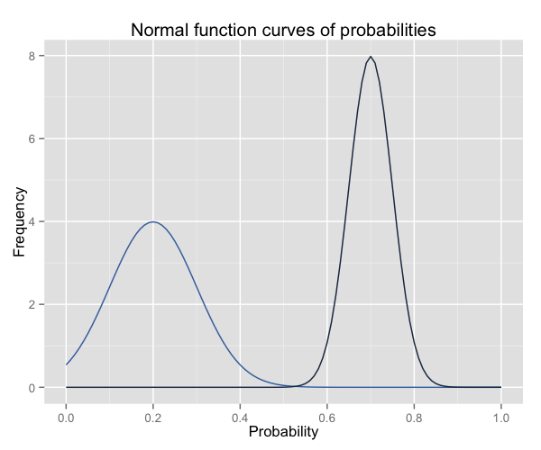

```r
p9 <- ggplot(data.frame(x = c(0, 1)), aes(x = x)) +
        stat_function(fun = dnorm, args = list(0.2, 0.1),
                      colour = "#4271AE") +
        stat_function(fun = dnorm, args = list(0.7, 0.05),
                      colour = "#1F3552") +
        scale_x_continuous(name = "Probability",
                              breaks = seq(0, 1, 0.2),
                              limits=c(0, 1)) +
        scale_y_continuous(name = "Frequency") +
        ggtitle("Normal function curves of probabilities")
p9
```

### Adding a legend

As we have added two separate commands to plot the two function curves, ggplot does not automatically recognise that it needs to create a legend. We can make a legend by swapping out the `colour` argument in each of the `stat_function` commands for `aes(colour = )`, and assigning it the name of the group. We also need to add the `scale_colour_manual` command to make the legend appear, and also assign colours and a title.

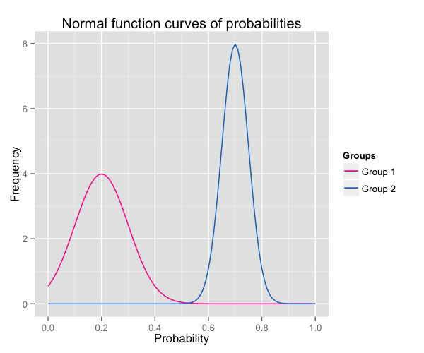

```r
p9 <- ggplot(data.frame(x = c(0, 1)), aes(x = x)) +
        stat_function(fun = dnorm, args = list(0.2, 0.1),
                      aes(colour = "Group 1")) +
        stat_function(fun = dnorm, args = list(0.7, 0.05),
                      aes(colour = "Group 2")) +
        scale_x_continuous(name = "Probability",
                              breaks = seq(0, 1, 0.2),
                              limits=c(0, 1)) +
        scale_y_continuous(name = "Frequency") +
        ggtitle("Normal function curves of probabilities") +
        scale_colour_manual("Groups", values = c("deeppink", "dodgerblue3"))
p9
```

If you want to use one of the automatic brewer palettes, you can swap `scale_colour_manual` for `scale_colour_brewer`, and call your favouite brewer colour scheme. You can see all of the brewer palettes using `display.brewer.all(5)` As this command doesn’t allow you to assign a title to the legend, you can assign a title using `labs(colour = "Groups")`.

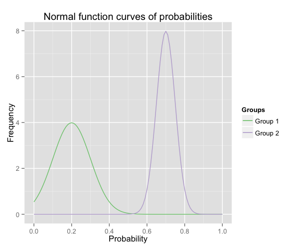

```r
p9 <- ggplot(data.frame(x = c(0, 1)), aes(x = x)) +
        stat_function(fun = dnorm, args = list(0.2, 0.1),
                      aes(colour = "Group 1")) +
        stat_function(fun = dnorm, args = list(0.7, 0.05),
                      aes(colour = "Group 2")) +
        scale_x_continuous(name = "Probability",
                              breaks = seq(0, 1, 0.2),
                              limits=c(0, 1)) +
        scale_y_continuous(name = "Frequency") +
        ggtitle("Normal function curves of probabilities") +
        scale_colour_brewer(palette="Accent") +
        labs(colour = "Groups")
p9
```

### Changing the size of the lines

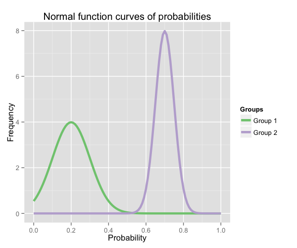

```r
p9 <- ggplot(data.frame(x = c(0, 1)), aes(x = x)) +
        stat_function(fun = dnorm, args = list(0.2, 0.1),
                      aes(colour = "Group 1"), size = 1.5) +
        stat_function(fun = dnorm, args = list(0.7, 0.05),
                      aes(colour = "Group 2"), size = 1.5) +
        scale_x_continuous(name = "Probability",
                              breaks = seq(0, 1, 0.2),
                              limits=c(0, 1)) +
        scale_y_continuous(name = "Frequency") +
        ggtitle("Normal function curves of probabilities") +
        scale_colour_brewer(palette="Accent") +
        labs(colour = "Groups")
p9
```

### Using the white theme

As explained in the previous posts, we can also change the overall look of the plot using themes. We’ll start using a simple theme customisation by adding `theme_bw()` after `ggplot()`. As you can see, we can further tweak the graph using the `theme` option, which we’ve used so far to change the legend.

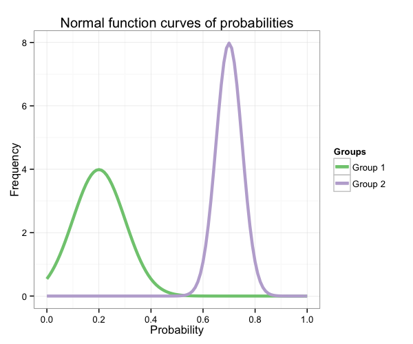

```r
p9 <- p9 + theme_bw()
p9
```

### Creating an XKCD style chart

Of course, you may want to create your own themes as well. `ggplot2` allows for a very high degree of customisation, including allowing you to use imported fonts. Below is an example of a theme Mauricio was able to create which mimics the visual style of [XKCD](http://xkcd.com/). In order to create this chart, you first need to import the XKCD font, install it on your machine and load it into R using the `extrafont` package. These instructions are taken from here:

```r
library(extrafont)

download.file("http://simonsoftware.se/other/xkcd.ttf",
              dest="xkcd.ttf", mode="wb")
system("mkdir ~/.fonts")
system("cp xkcd.ttf  ~/.fonts")
font_import(paths = "~/.fonts", pattern="[X/x]kcd")
fonts()
loadfonts()
```

You can then create your graph:

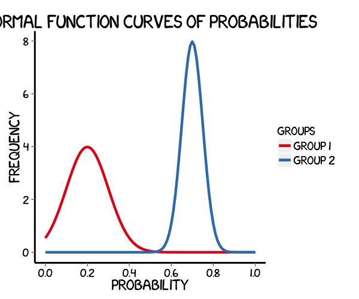

```r
p9 <- ggplot(data.frame(x = c(0, 1)), aes(x = x)) +
        stat_function(fun = dnorm, args = list(0.2, 0.1),
                      aes(colour = "Group 1"), size = 1.5) +
        stat_function(fun = dnorm, args = list(0.7, 0.05),
                      aes(colour = "Group 2"), size = 1.5) +
        scale_x_continuous(name = "Probability",
                              breaks = seq(0, 1, 0.2),
                              limits=c(0, 1)) +
        scale_y_continuous(name = "Frequency") +
        ggtitle("Normal function curves of probabilities") +
        scale_colour_brewer(palette="Set1") +
        labs(colour = "Groups") +
        theme(axis.line = element_line(size=1, colour = "black"),
              panel.grid.major = element_blank(),
              panel.grid.minor = element_blank(),
              panel.border = element_blank(),
              panel.background = element_blank(),
              plot.title=element_text(size = 20, family="xkcd-Regular"),
              text=element_text(size = 16, family="xkcd-Regular"),
              axis.text.x=element_text(colour="black", size = 12),
              axis.text.y=element_text(colour="black", size = 12))
p9
```

### Using ‘The Economist’ theme

There are a wider range of pre-built themes available as part of the `ggthemes` package (more information on these [here](https://cran.r-project.org/web/packages/ggthemes/vignettes/ggthemes.html)). Below we’ve applied `theme_economist()`, which approximates graphs in the Economist magazine.

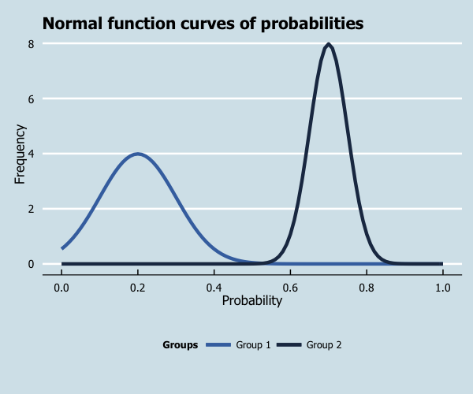

```r
library(ggthemes)

p9 <- ggplot(data.frame(x = c(0, 1)), aes(x = x)) +
        stat_function(fun = dnorm, args = list(0.2, 0.1),
                      aes(colour = "Group 1"), size = 1.5) +
        stat_function(fun = dnorm, args = list(0.7, 0.05),
                      aes(colour = "Group 2"), size = 1.5) +
        scale_x_continuous(name = "Probability",
                              breaks = seq(0, 1, 0.2),
                              limits=c(0, 1)) +
        scale_y_continuous(name = "Frequency") +
        ggtitle("Normal function curves of probabilities") +
        scale_colour_manual("Groups", values = c("#4271AE", "#1F3552")) +
        theme_economist() +
        theme(legend.position = "bottom", legend.direction = "horizontal",
              legend.box = "horizontal",
              legend.key.size = unit(1, "cm"),
              plot.title = element_text(family="Tahoma"),
              text = element_text(family = "Tahoma"),
              axis.title = element_text(size = 12),
              legend.text = element_text(size = 9),
              legend.title=element_text(face = "bold", size = 9))
p9
```

### Creating your own theme

As before, you can modify your plots a lot as `ggplot2` allows many customisations. Here is a custom plot where we have modified the axes, background and font.

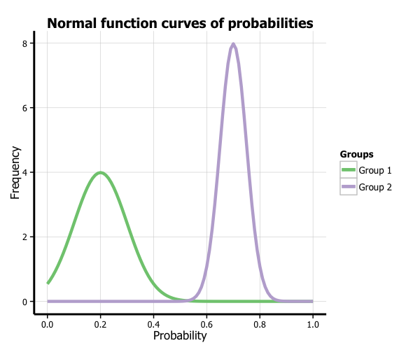

```r
library(grid)

p9 <- ggplot(data.frame(x = c(0, 1)), aes(x = x)) +
        stat_function(fun = dnorm, args = list(0.2, 0.1),
                      aes(colour = "Group 1"), size = 1.5) +
        stat_function(fun = dnorm, args = list(0.7, 0.05),
                      aes(colour = "Group 2"), size = 1.5) +
        scale_x_continuous(name = "Probability",
                              breaks = seq(0, 1, 0.2),
                              limits=c(0, 1)) +
        scale_y_continuous(name = "Frequency") +
        ggtitle("Normal function curves of probabilities") +
        scale_colour_brewer(palette="Accent") +
        labs(colour = "Groups") +
        theme_bw() +
        theme(axis.line = element_line(size=1, colour = "black"),
              panel.grid.major = element_line(colour = "#d3d3d3"),
              panel.grid.minor = element_blank(),
              panel.border = element_blank(), panel.background = element_blank(),
              plot.title = element_text(size = 14, family = "Tahoma", face = "bold"),
              text=element_text(family="Tahoma"),
              axis.text.x=element_text(colour="black", size = 9),
              axis.text.y=element_text(colour="black", size = 9))
p9
```

### Adding areas under the curve

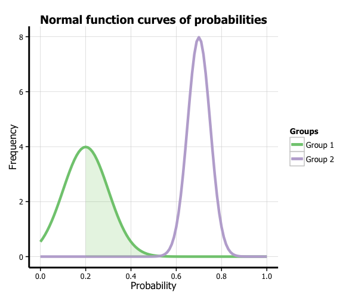

```r
funcShaded <- function(x) {
    y <- dnorm(x, mean = 0.2, sd = 0.1)
    y[x < 0.2 | x > (0.2 + 4 * 0.1)] <- NA
    return(y)
}

p9 <- p9 + stat_function(fun=funcShaded, geom="area", fill="#84CA72", alpha=0.2)
p9
```

### Formatting the legend

Finally, we can format the legend by changing the position. We simply add the `legend.position = "bottom"` argument to the `theme` option, which moves the legend under the plot.

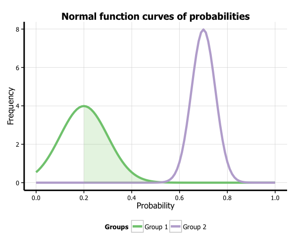

```r
p9 <- ggplot(data.frame(x = c(0, 1)), aes(x = x)) +
        stat_function(fun = dnorm, args = list(0.2, 0.1),
                      aes(colour = "Group 1"), size = 1.5) +
        stat_function(fun = dnorm, args = list(0.7, 0.05),
                      aes(colour = "Group 2"), size = 1.5) +
        stat_function(fun=funcShaded, geom="area", fill="#84CA72", alpha=0.2) +
        scale_x_continuous(name = "Probability",
                              breaks = seq(0, 1, 0.2),
                              limits=c(0, 1)) +
        scale_y_continuous(name = "Frequency") +
        ggtitle("Normal function curves of probabilities") +
        scale_colour_brewer(palette="Accent") +
        labs(colour = "Groups") +
        theme_bw() +
        theme(axis.line = element_line(size=1, colour = "black"),
              panel.grid.major = element_line(colour = "#d3d3d3"),
              panel.grid.minor = element_blank(),
              panel.border = element_blank(), panel.background = element_blank(),
              plot.title = element_text(size = 14, family = "Tahoma", face = "bold"),
              text=element_text(family="Tahoma"),
              axis.text.x=element_text(colour="black", size = 9),
              axis.text.y=element_text(colour="black", size = 9),
              legend.position = "bottom")
p9
```